# Hate Crime Analysis across the United States

Yannis Panagis

17/11/2019

## Preliminary

This is an exercise to pose a research question using data science techniques. The following explains the relevance of the topic, describes the statistical methodology used to answer the question and present new findings. This project is loosely structured as an introduction, a survey of related work, methods, data and useful summaries, results and conclusions.

## Introduction

Only ten days after the 2016 election, more than 900 hate crime incidents were reported to the Southern Poverty Law Center. This averages out to approximately 90 incidents per day, while the average number of incidents per day based on data collected between 2010 and 2015 indicated an average of only 16 incidents per day. This significant difference before and after the election raises the question whether there were more hate crime incidents after the 2016 election. However, as prior research conducted by the FiveThirtyEight proposes, there are several limitations in the data available so it is not possible to definitively determine whether hate crime rates have increased.

Instead, this research question examines which factor in the given data is the best predictor of hate crime rates across the states in the United States and how hate crimes vary geographically by state.

Previous analysis has proposed that the best predictor of hate crimes and incidents is income inequality. For the purposes of this investigation, several factors will be evaluated to determine whether there is a statistically significant relationship between variables such as median house income, the share of the population that is unemployed, the share of the population that has a high school degree, and other factors such as the Gini index and the share of 2016 U.S. presidential voters who voted for Donald Trump.

The sources for the dataset being used for this analysis are the FBI and the Southern Poverty Law Center. While these particular data sources can be considered realiable sources of information several problems arise when considering the sources of the data being used for this analysis. Firstly, the data provided by the federal government uses information that agencies voluntarily report to the FBI and so they do not have any systematic method for tracking hate crimes. The federal government data also only includes information regarding to prosecutable incidents which do not represent all hate crimes as several offenses that are not prosecutable have been ommitted such as white nationalist recruitment distribution.

Secondly, the dataset is not entirely complete and as the initial visual plots included below demonstrate, some states, such as Hawaii, are missing from the database. The limitation that arises when using data provided by the SPLC is that it uses reputable media accounts and personal accounts or reports to assess incidents and further that there is no data available by the SPLC before the election in 2016. Both of these sources also include a bias because they are based on information obtained by voluntary submission so it may not be truly or completely representative of the true situation. The SPLC data does however have the advantage of including data on both prosecutable and non-prosecutable hate incidents, though previous related work has also proposed that an awareness bias may also skew the data as it is self-reported and awareness of hate crimes has changed since the 2016 Presidential election.

RESEARCH QUESTION

Which factor in the given data is the best predictor of hate crime rates across the states in the United States and how do hate crimes vary geographically by state?

THE DATASET

## Loading the dataset

```r
## install.packages("fivethirtyeight")
library(fivethirtyeight)
library(tidyverse)
```

```r
library(knitr)
library(ggplot2)
require(fivethirtyeight)
data(hate_crimes, package = "fivethirtyeight")

## ?hate_crimes
head(hate_crimes)
```

```
## # A tibble: 6 x 12
##   state median_house_inc share_unemp_seas share_pop_metro share_pop_hs
##   <chr>            <int>            <dbl>           <dbl>        <dbl>
## 1 Alab…            42278            0.06             0.64        0.821
## 2 Alas…            67629            0.064            0.63        0.914
## 3 Ariz…            49254            0.063            0.9         0.842
## 4 Arka…            44922            0.052            0.69        0.824
## 5 Cali…            60487            0.059            0.97        0.806
## 6 Colo…            60940            0.04             0.8         0.893
## # ... with 7 more variables: share_non_citizen <dbl>,
## #   share_white_poverty <dbl>, gini_index <dbl>, share_non_white <dbl>,
## #   share_vote_trump <dbl>, hate_crimes_per_100k_splc <dbl>,
## #   avg_hatecrimes_per_100k_fbi <dbl>
```

```r
summary(hate_crimes)
```

```
##     state           median_house_inc share_unemp_seas  share_pop_metro
##  Length:51          Min.   :35521    Min.   :0.02800   Min.   :0.3100
##  Class :character   1st Qu.:48657    1st Qu.:0.04200   1st Qu.:0.6300
##  Mode  :character   Median :54916    Median :0.05100   Median :0.7900
##                     Mean   :55224    Mean   :0.04957   Mean   :0.7502
##                     3rd Qu.:60719    3rd Qu.:0.05750   3rd Qu.:0.8950
##                     Max.   :76165    Max.   :0.07300   Max.   :1.0000
##
##   share_pop_hs    share_non_citizen share_white_poverty   gini_index
##  Min.   :0.7990   Min.   :0.01000   Min.   :0.04000     Min.   :0.4190
##  1st Qu.:0.8405   1st Qu.:0.03000   1st Qu.:0.07500     1st Qu.:0.4400
##  Median :0.8740   Median :0.04500   Median :0.09000     Median :0.4540
##  Mean   :0.8691   Mean   :0.05458   Mean   :0.09176     Mean   :0.4538
##  3rd Qu.:0.8980   3rd Qu.:0.08000   3rd Qu.:0.10000     3rd Qu.:0.4665
##  Max.   :0.9180   Max.   :0.13000   Max.   :0.17000     Max.   :0.5320
##                   NA's   :3
##  share_non_white  share_vote_trump hate_crimes_per_100k_splc
##  Min.   :0.0600   Min.   :0.040    Min.   :0.06745
##  1st Qu.:0.1950   1st Qu.:0.415    1st Qu.:0.14271
##  Median :0.2800   Median :0.490    Median :0.22620
##  Mean   :0.3157   Mean   :0.490    Mean   :0.30409
##  3rd Qu.:0.4200   3rd Qu.:0.575    3rd Qu.:0.35694
##  Max.   :0.8100   Max.   :0.700    Max.   :1.52230
##                                    NA's   :4
##  avg_hatecrimes_per_100k_fbi
##  Min.   : 0.2669
##  1st Qu.: 1.2931
##  Median : 1.9871
##  Mean   : 2.3676
##  3rd Qu.: 3.1843
##  Max.   :10.9535
##  NA's   :1
```

## Visual plots showing hate crime incidents pre- and post- of the 2016 US Presidential Election

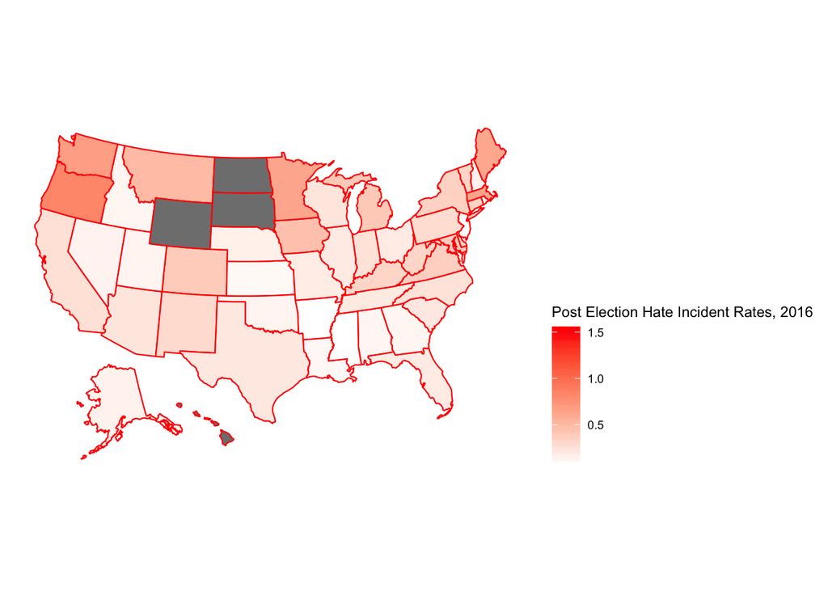

```r
## install.packages("usmap")
library(usmap)
require(usmap)

## general syntax for making maps by us state to use in your visualizations section

usmap::plot_usmap(data = hate_crimes, values = "hate_crimes_per_100k_splc", lines = "red") +
  scale_fill_continuous(
    low = "white", high = "red", name = "Post Election Hate Incident Rates, 2016", label = scales::comma
  ) + theme(legend.position = "right")
```

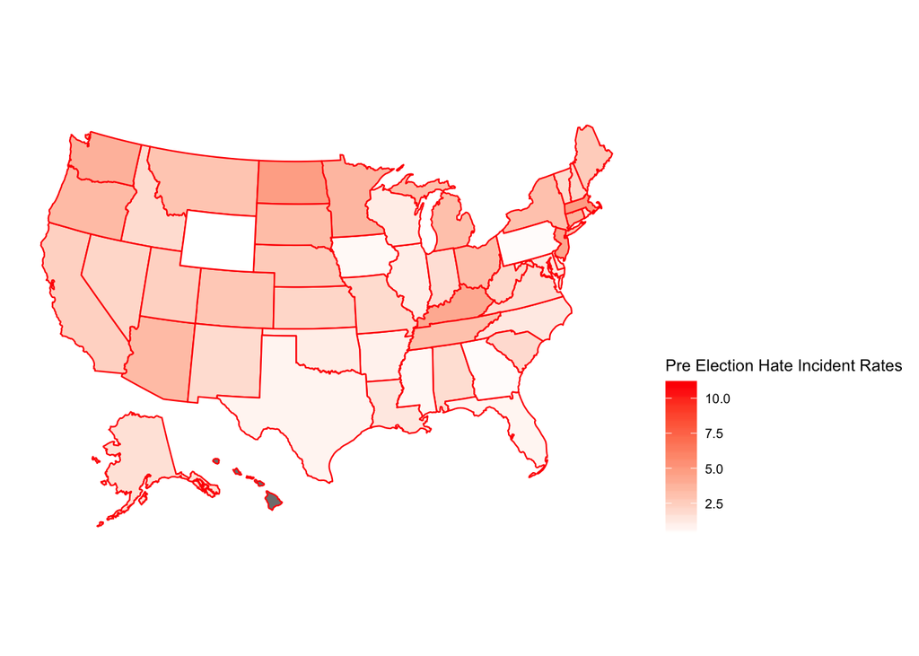

```r
usmap::plot_usmap(data = hate_crimes, values = "avg_hatecrimes_per_100k_fbi", lines = "red") +
  scale_fill_continuous(
    low = "white", high = "red", name = "Pre Election Hate Incident Rates", label = scales::comma
  ) + theme(legend.position = "right")
```

The visual plots above visualise the change in pre and post election hate incident rates as there is a clear variation before and after for the states. The plots further demonstrate that hate incident rates are not uniformly distributed across the United States and different states have varying hate crime rates both before and after the 2016 Election. It is also important to note that these plots also clearly point out which data is missing from the dataset from before and after the election. For example, there is no data available on Hawaii before the election and there is no data available on Hawaii, North Dakota, South Dakota, and Wyoming, which means that the data is also not fully representative of the entire population because of missing entries for some of the states.

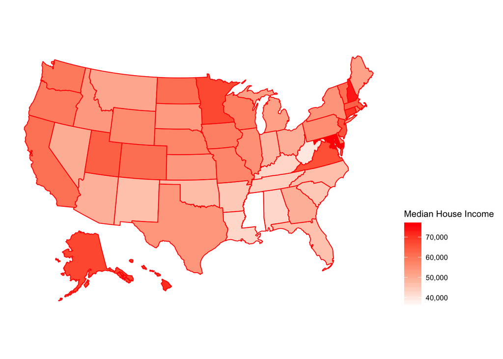

```r
usmap::plot_usmap(data = hate_crimes, values = "median_house_inc", lines = "red") +
  scale_fill_continuous(
    low = "white", high = "red", name = "Median House Income", label = scales::comma
  ) + theme(legend.position = "right")
```

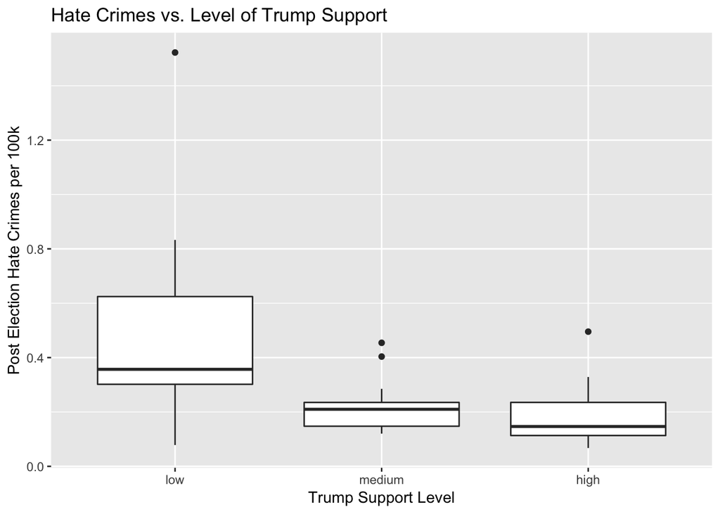

```r
# In this next plot we create a categorical variable of Trump support level (into three categories: low, medium and high) based on the numerical variable in the dataset of the proprotion of 2016 US presidential voters who voted for Donald Trump.

hate_crimes_alternate <- hate_crimes %>%
  mutate(
    trump_support_level = cut_number(share_vote_trump, 3, labels=c("low", "medium", "high"))
    )

g1 <- ggplot(data=hate_crimes_alternate, mapping = aes(x=trump_support_level, y=hate_crimes_per_100k_splc))
g1 <- g1 + geom_boxplot() + labs(x= "Trump Support Level", y= "Post Election Hate Crimes per 100k", title= "Hate Crimes vs. Level of Trump Support")
g1
```

ANALYSIS AND LINEAR REGRESSION TESTING

The analysis of this dataset was started using the lm function to fit a simple linear regression model, with `avg_hatecrimes_per_100k_fbi` as the response and `share_vote_trump` as the predictor. The object returned by this function was then stored as `lm.fit`

```r
lm.fit <- lm(avg_hatecrimes_per_100k_fbi ~ share_vote_trump, data = hate_crimes)
```

The following 3 chunks of code output some basic information about the model such as the p-values and standard errors for the coefficients, as well as the $R^2$ statistic and F-statistic for the model.

```r
lm.fit
```

```
##
## Call:
## lm(formula = avg_hatecrimes_per_100k_fbi ~ share_vote_trump,
##     data = hate_crimes)
##
## Coefficients:
##      (Intercept)  share_vote_trump
##            6.026            -7.409
```

```r
summary(lm.fit)
```

```
##
## Call:
## lm(formula = avg_hatecrimes_per_100k_fbi ~ share_vote_trump,
##     data = hate_crimes)
##
## Residuals:
##     Min      1Q  Median      3Q     Max
## -2.1081 -1.1586 -0.0971  0.8863  5.2238
##
## Coefficients:
##                  Estimate Std. Error t value Pr(>|t|)
## (Intercept)        6.0260     0.9281   6.493 4.41e-08 ***
## share_vote_trump  -7.4087     1.8300  -4.049 0.000187 ***
## ---
## Signif. codes:  0 '***' 0.001 '**' 0.01 '*' 0.05 '.' 0.1 ' ' 1
##
## Residual standard error: 1.495 on 48 degrees of freedom
##   (1 observation deleted due to missingness)
## Multiple R-squared:  0.2546, Adjusted R-squared:  0.239
## F-statistic: 16.39 on 1 and 48 DF,  p-value: 0.0001869
```

```r
coef(lm.fit)
```

```
##      (Intercept) share_vote_trump
##         6.026039        -7.408721
```

```r
confint(lm.fit)
```

```
##                       2.5 %    97.5 %
## (Intercept)        4.160062  7.892017
## share_vote_trump -11.088113 -3.729329
```

The confidence interval generated for the variable share_vote_trump is not particularly meaningful because the values are below zero at the 2.5th and 97.5th percentiles so this cannot be used as a particularly meaningful metric in this analysis.

```r
predict(lm.fit, data.frame(share_vote_trump = c(5, 10, 15)),
       interval = "confidence")
```

```
##          fit        lwr       upr
## 1  -31.01757  -47.60309 -14.43204
## 2  -68.06117 -103.04079 -33.08155
## 3 -105.10478 -158.48047 -51.72908
```

```r
predict(lm.fit, data.frame(share_vote_trump = c(5, 10, 15)),
       interval = "prediction")
```

```
##          fit        lwr       upr
## 1  -31.01757  -47.87343 -14.16170
## 2  -68.06117 -103.16978 -32.95256
## 3 -105.10478 -158.56509 -51.64446
```

At a first glance, it is unclear why the intervals generated by the two functions above are different. The reason that the confidence interval and the prediction interval are different is because the confidence interval is a the range of plausible values for the **mean** of $y$, while the **prediction** interval gives the range of possible values for a single **new** value of $y$.

An alternative approach

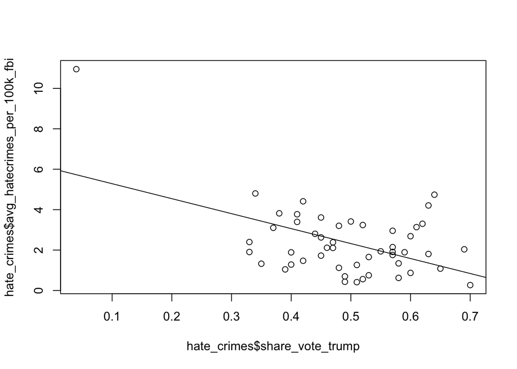

```r
plot(hate_crimes$share_vote_trump, hate_crimes$avg_hatecrimes_per_100k_fbi)
abline(lm.fit)
```

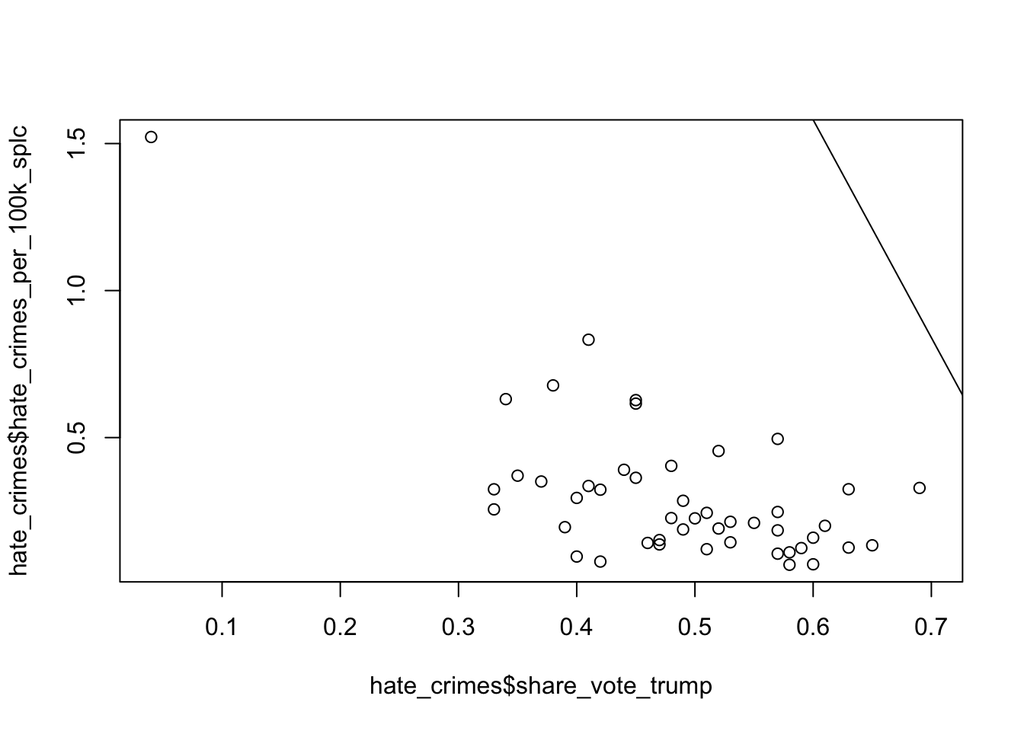

```r
plot(hate_crimes$share_vote_trump, hate_crimes$hate_crimes_per_100k_splc)
abline(lm.fit)
```

In order to further analyse the data we must consider the diagnostic plots, shown below.

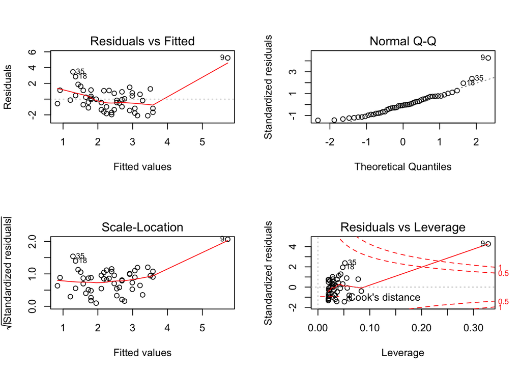

```r
par(mfrow=c(2,2))
plot(lm.fit)
```

## So what do these plots actually tell us?

As the QQ plot is a scatter plot created by plotting the two sets of quantiles against each other it demonstrates that both sets of quantiles came from the same distribution because they roughly follow a straight line. This plot suggests that it is plausible that there is a linear relationship between the variable share_trump_voters and the number of hate incidents per 100k.

The “Scale-location” can be interpreted similarly to the “residuals vs fitted” plot because the standardized residuals are the residuals diviuded by their estimated standard deviations and in a linear model the estimated standard deviation of the residuals depends on the value of x. Similarly, as this plot is also not a horizontal line it also suggests that that the data cannot be modelled by a linear regression, despite the initial plots that indicated a linear relationship previously.

The “Residuals vs. leverage” plots the values of the residuals against the leverage which measures the influence of each observation on the fit. The points with a high leverage shown pull the regression line more towawrds them than the other points and this is problematic in this particular case because the residual values for those points are high and this suggests that the point is both pulling the line toward it and that the model is still not fitting well. These points could be considered outliers for which the model is not appropriate because they skew the data.

Alternatively, the residuals can also be computed from a linear regression fit and the studentized residuals obtained by using the function rstudent() may be more interpretable because the studentized residuals standardise the residuals by diving by this estimated standard deviation.

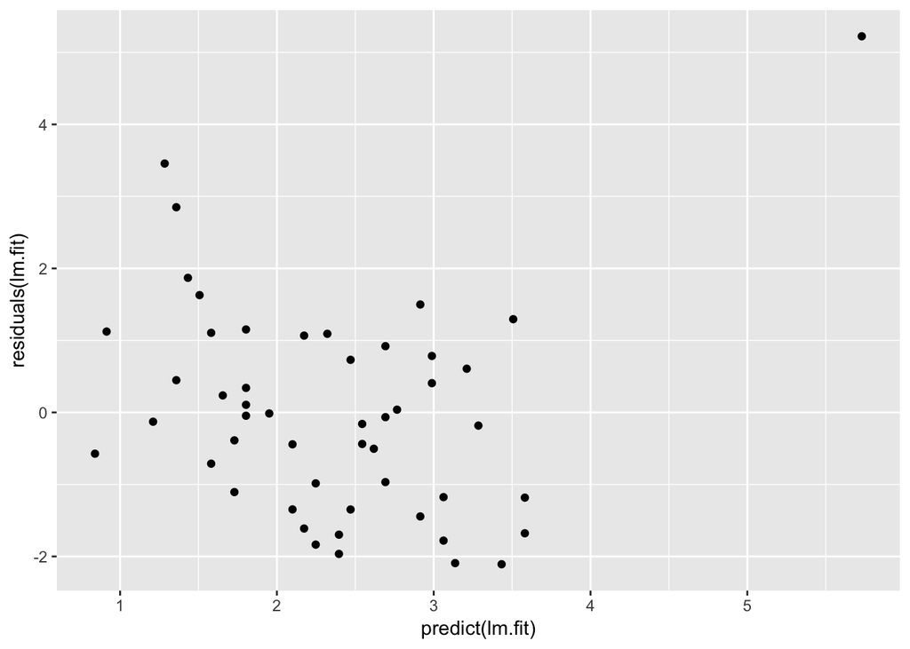

```r
qplot(predict(lm.fit), residuals(lm.fit))
```

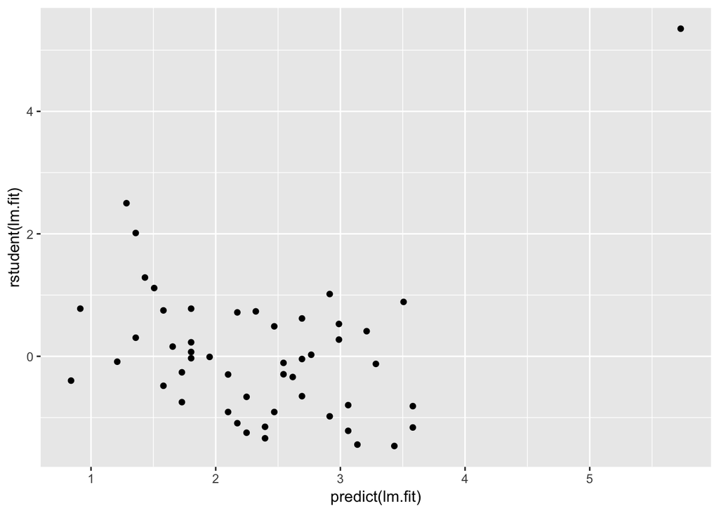

```r
qplot(predict(lm.fit), rstudent(lm.fit))
```

The conclusion that can be made in our analysis so far is that alone, the share of trump voters is not a clear predictor of the number of hate crime incidents before or after the election, even though it is possible that there is a relationship there is not enough evidence to verify this based on this initial analysis.

The clearest way answer the research question as to which of the variables in the dataset is the best predictor of the number of hate crime incidents is to determine which predictors have the largest estimated coefficients if the relative magnitude is interpretable.

Which of the variables are statistically significant?

```r
lm.fit1 <- lm(avg_hatecrimes_per_100k_fbi ~ . -state, data=hate_crimes)
summary(lm.fit1)
```

```
##
## Call:
## lm(formula = avg_hatecrimes_per_100k_fbi ~ . - state, data = hate_crimes)
##
## Residuals:
##      Min       1Q   Median       3Q      Max
## -1.91926 -0.72609  0.02257  0.54873  1.98454
##
## Coefficients:
##                             Estimate Std. Error t value Pr(>|t|)
## (Intercept)               -2.693e+01  1.649e+01  -1.634 0.111584
## median_house_inc           2.763e-05  4.355e-05   0.634 0.530022
## share_unemp_seas           2.519e+01  2.370e+01   1.063 0.295312
## share_pop_metro           -1.693e+00  1.733e+00  -0.976 0.335776
## share_pop_hs               1.023e+01  1.230e+01   0.832 0.411109
## share_non_citizen          1.806e+01  1.113e+01   1.623 0.113929
## share_white_poverty        1.385e+00  1.406e+01   0.099 0.922067
## gini_index                 3.620e+01  1.436e+01   2.521 0.016542 *
## share_non_white           -2.737e+00  2.444e+00  -1.120 0.270670
## share_vote_trump           2.202e+00  3.269e+00   0.673 0.505196
## hate_crimes_per_100k_splc  3.768e+00  1.046e+00   3.604 0.000991 ***
## ---
## Signif. codes:  0 '***' 0.001 '**' 0.01 '*' 0.05 '.' 0.1 ' ' 1
##
## Residual standard error: 1.11 on 34 degrees of freedom
##   (6 observations deleted due to missingness)
## Multiple R-squared:  0.6779, Adjusted R-squared:  0.5832
## F-statistic: 7.156 on 10 and 34 DF,  p-value: 6.084e-06
```

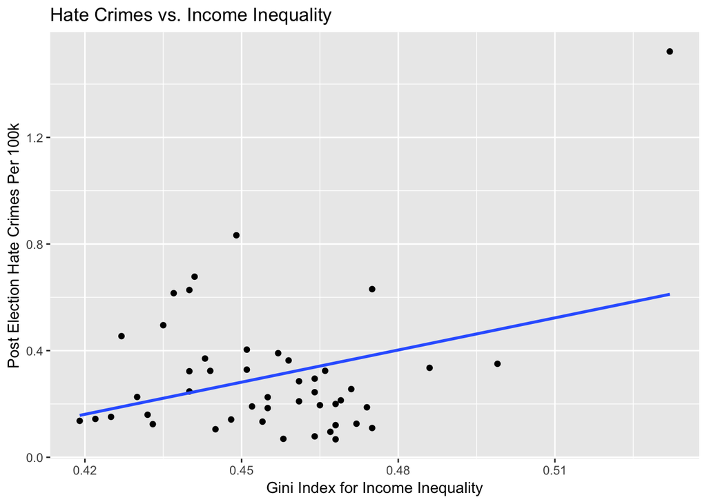

```r
g2 <- ggplot(data=hate_crimes, mapping = aes(x=gini_index, y=hate_crimes_per_100k_splc))
g2 <- g2 + geom_point() + geom_smooth(method = "lm", se=FALSE)
g2 <- g2 + labs(x = "Gini Index for Income Inequality", y = "Post Election Hate Crimes Per 100k", title = "Hate Crimes vs. Income Inequality")
g2
```

The Gini coefficient is best interpreted as a measure of income or wealth dispersion, or in other words, income inequality. A value of 0 for the Gini index would indicate perfect equality and a value of 1 for the Gini index would indicate perfect inequality. The reason for this direct linear relationship proposed by the p-value and the graph above could be that income inequality is known to have a significant effect on violence in neighborhoods and communities in general, and as originally proposed by FiveThirtyEight’s analysis, hate crimes can be considered a special case of a larger category of violence.

However, it is important to consider the limitations of this analysis because while there may be a statistically significant correlation in the data, correlation does not necessarily imply causation.

```r
lm.fit2 <- lm(hate_crimes_per_100k_splc ~ median_house_inc + gini_index -state, data=hate_crimes)
summary(lm.fit2)
```

```
##
## Call:
## lm(formula = hate_crimes_per_100k_splc ~ median_house_inc + gini_index -
##     state, data = hate_crimes)
##
## Residuals:
##      Min       1Q   Median       3Q      Max
## -0.38128 -0.13719 -0.05628  0.07650  0.70803
##
## Coefficients:
##                    Estimate Std. Error t value Pr(>|t|)
## (Intercept)      -2.454e+00  7.762e-01  -3.161  0.00284 **
## median_house_inc  1.107e-05  3.554e-06   3.116  0.00322 **
## gini_index        4.722e+00  1.588e+00   2.973  0.00477 **
## ---
## Signif. codes:  0 '***' 0.001 '**' 0.01 '*' 0.05 '.' 0.1 ' ' 1
##
## Residual standard error: 0.2208 on 44 degrees of freedom
##   (4 observations deleted due to missingness)
## Multiple R-squared:  0.2697, Adjusted R-squared:  0.2365
## F-statistic: 8.124 on 2 and 44 DF,  p-value: 0.0009934
```

## CONCLUSION

The initial research on this subject by the SPLC has additionally proposed that “Socioeconomic drivers for hate incidents at the community level may differ from the state-level indicators that we identified here. Moreover, it is likely that neither data set is truly representative of hate incidents across the United States, and it’s possible that whether people report or don’t report these incidents is different among states.” This means that the FBI and SPLC datasets may be misrepresentative because the number of reported incidents may be underreported in several states and so the data may not be truly represantitive of hate crime incidents across the United States, as initially proposed in the introduction of this analysis.

Despite these limitations, both data sets reveal that hate incidents aren’t uniformly distributed across the United States. In other words, a greater number of hate incidents were reported in some states (per 100,000 people) than in others — both according to the SPLC after the election and the FBI before it.